# Lights Out in Afghanistan

Effects of the 2021 Taliban Takeover

Author

Camron Ibrahimi

Published

October 19, 2026

Abstract

After the Taliban took Kabul in August 2021, Afghanistan lost most foreign aid, access to its central bank reserves and its links to the international banking system. The economic consequences were measured using satellite nighttime lights from NASA’s Black Marble monthly product for 2018–2023. Afghanistan was compared with six control countries in South and Central Asia and also the Philippines in a difference-in-differences regression analysis. Afghanistan’s lit radiance falls by about 52% relative to the comparison countries and the decline persists for at least two years. The pre-takeover trend is close to flat and the result holds across radiance thresholds and sample restrictions. A permutation test finds that no comparison country shows a larger decline.

Keywords

Afghanistan, nighttime lights, difference-in-differences, sanctions

# 1 Introduction

On 15 August 2021, Taliban forces entered Kabul and the internationally recognised government (Islamic Republic of Afghanistan) collapsed. This was the same government that was previously backed, financed and protected by the United States and its NATO allies. The economic shock that followed was not mainly a result of fighting, but of the suspension of donor grants, which had previously funded most public spending. Afghanistan’s central bank lost access to its reserves held abroad. Correspondent banks cut ties with the Afghan financial system as a result. This disrupted trade payments in particular and the remittances many households depended on (World Bank 2022).

Measuring what followed shortly after is hard, because official statistics largely stopped. This note uses an outcome that does not depend on the Afghan state: light visible from space at night. Nighttime lights track economic activity well where national accounts may be weak or simply missing (Henderson, Storeygard, and Weil 2012; Chen and Nordhaus 2011).

Afghanistan’s lights were compared with those of 7 comparison countries before and after the takeover. The main estimate is a **52%** decline in lit radiance relative to the comparison group. The fall began with the Taliban offensive in mid-2021 and was yet to reverse by the end of 2023.

# 2 Data

**Nighttime lights.** NASA’s Black Marble VNP46A3 monthly product (Román et al. 2018), which corrects VIIRS radiance for moonlight, atmosphere and cloud cover. The panel covers 72 months (January 2018 to December 2023) for 8 countries. National boundaries come from Natural Earth.

**Measuring “lights”.** Most of Afghanistan is dark, so averages over all pixels are dominated by noise. The product records radiance below 0.5 nW as zero and a large number of faint background pixels just above that floor made the national mean jump in 2023, while brighter, clearly lit areas remained constant. The outcome is therefore the **log of total radiance from pixels brighter than 2 nW**, which isolates settled, lit areas. Thresholds of 1 nW and 5 nW give similar results (Section 5).

**Comparison countries.** Bangladesh, Kyrgyzstan, Nepal, Pakistan, the Philippines, Tajikistan and Uzbekistan. These are lower- and middle-income countries in or near the region that also rely on remittances.

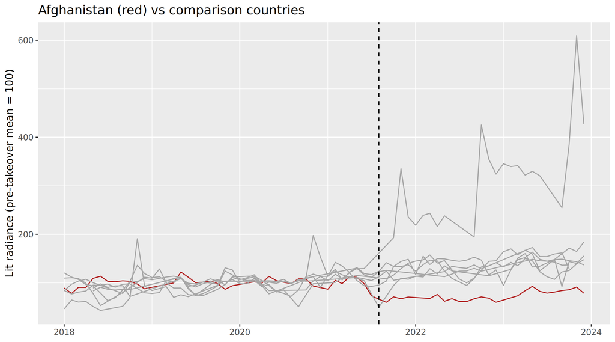

Figure 1: Lit radiance (> 2 nW) indexed to each country’s pre-takeover mean. Afghanistan in red. Dashed line: August 2021.

# 3 Empirical strategy

The estimated difference-in-differences model is

$$\log L_{ct} = \alpha_{c,m(t)} + \lambda_t + \beta \,(\text{Afghanistan}_c \times \text{Post}_t) + \varepsilon_{ct}$$

where $L_{ct}$ is lit radiance in country $c$ and month $t$, and $\text{Post}_t$ equals one from August 2021. The country-by-calendar-month effects $\alpha_{c,m(t)}$ absorb each country’s own seasonal pattern (for example festival lighting or winter heating). The month effects $\lambda_t$ absorb shocks common to all countries, such as COVID-19. $\beta$ measures how much Afghanistan’s lights changed after the takeover beyond the change in the comparison countries.

To check the timing, an event study was estimated. This replaced $\text{Post}_t$ with indicators for each year relative to the takeover, where each year runs from August to July. The reference year is August 2019 to July 2020, well before the 2021 offensive.

**Inference.** With one treated country and 7 controls, conventional clustered standard errors are unreliable (Conley and Taber 2011; Cameron, Gelbach, and Miller 2008). The main evidence is a permutation test in the spirit of Abadie, Diamond, and Hainmueller (2010): each comparison country is analysed in turn as if it had been “treated”, to see how unusual Afghanistan’s estimate truly is.

# 4 Results

Table 1: Difference-in-differences estimates. Standard errors clustered by country in parentheses.

|  | Estimate | % change | N |
| --- | --- | --- | --- |
| Main (> 2 nW) | -0.732 (0.114) | -52% | 442 |
| > 1 nW | -0.691 (0.113) | -50% | 442 |
| > 5 nW | -0.828 (0.122) | -56% | 442 |
| Drop Pakistan | -0.767 (0.135) | -54% | 371 |
| Drop Nepal | -0.627 (0.032) | -47% | 388 |
| Drop Aug 2021 | -0.735 (0.116) | -52% | 435 |
| Drop May–Jul 2021 | -0.756 (0.118) | -53% | 422 |
| No coverage filter | -0.765 (0.133) | -53% | 576 |

Table 1 reports the estimates. In the main specification, Afghanistan’s lit radiance falls by 0.73 log points (standard error 0.11) relative to the comparison countries, a decline of about **52%**. Figure 1 shows where this comes from: Afghanistan tracks the other countries until mid-2021, then drops and stays down while the comparison countries recover from COVID-19.

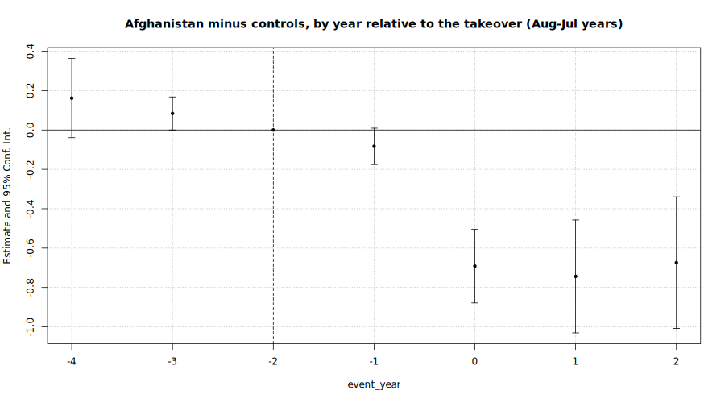

Figure 2: Event study: Afghanistan minus comparison countries, by year relative to the takeover (August–July years). Reference year −2 (Aug 2019–Jul 2020). Bars are 95% confidence intervals clustered by country.

Figure 2 shows the timing. The two earliest years lie slightly above zero (0.16 and 0.08), and year −1, which includes the start of the Taliban offensive, is -0.08. After the takeover the estimates drop to between -0.74 and -0.67 and stay there for all three post-takeover years (the last observed only through December 2023). The effect does not seem to fade.

# 5 Inference and robustness

**Permutation test.** When “treatment” is re-assigned to each country in turn, Afghanistan’s estimate ranks 1 of 8: no comparison country shows a larger decline. The one-sided permutation p-value is 0.125. This is the smallest value possible with 8 countries, so it is the strongest evidence this test can give. It should be read as “Afghanistan is the most extreme case in the sample”, not simply as significance at conventional levels.

**Placebo in time.** Using only data up to April 2021 and pretending the takeover happened in August 2019 gives an estimate of -0.09 (p = 0.16), close to zero, as it should be if nothing unusual was happening to Afghanistan before 2021.

**Specification checks.** Table 1 shows that the result holds for radiance thresholds of 1, 2 and 5 nW, without the coverage filter, and when dropping the takeover month or the offensive months of May–July 2021. Dropping Pakistan or Nepal also leaves the estimate largely unchanged.

# 6 Limitations

- **Few countries.** With only one treated country, the inference relies on a permutation test with only 8 possible outcomes. Clustered standard errors with so few clusters can be misleadingly small. The “Drop Nepal” row, with an unusually small standard error, is an example.
- **Mild pre-trend.** Afghanistan’s lights were drifting slightly down relative to the comparison countries before 2021. The drift is small next to the post-takeover drop, but it means that part of the estimate could reflect an earlier decline.
- **Contaminated controls.** Pakistan borders Afghanistan, trades heavily with the country and received refugees after the takeover, so it was affected too. Nepal’s lights grew unusually fast over the period. Neither country drives the result (Table 1), but no comparison group can ever be perfect.
- **What lights measure.** Lights capture electricity use and visible economic activity, not income directly. Some of the decline may also reflect cuts in electricity imports or public lighting, not only lower private activity.
- **Mechanisms.** This design measures the combined effect of the takeover. It cannot separate the aid cut-off, the banking freeze, the disruption to remittances and the changes in governance.

# 7 Conclusion

Satellite data show a large and lasting fall in Afghanistan’s economic activity after August 2021: lit radiance fell by about 52% relative to comparable countries, with no recovery by the end of 2023. Because the outcome is measured from space, this estimate does not depend on official statistics, which largely stopped after the takeover. A natural next step would be to use subnational data, comparing provinces that relied more on aid or remittances before 2021, in order to separate the channels behind the decline.

# References

Abadie, Alberto, Alexis Diamond, and Jens Hainmueller. 2010. “Synthetic Control Methods for Comparative Case Studies: Estimating the Effect of California’s Tobacco Control Program.” *Journal of the American Statistical Association* 105 (490): 493–505. https://doi.org/10.1198/jasa.2009.ap08746.

Cameron, A. Colin, Jonah B. Gelbach, and Douglas L. Miller. 2008. “Bootstrap-Based Improvements for Inference with Clustered Errors.” *Review of Economics and Statistics* 90 (3): 414–27. https://doi.org/10.1162/rest.90.3.414.

Chen, Xi, and William D. Nordhaus. 2011. “Using Luminosity Data as a Proxy for Economic Statistics.” *Proceedings of the National Academy of Sciences* 108 (21): 8589–94. https://doi.org/10.1073/pnas.1017031108.

Conley, Timothy G., and Christopher R. Taber. 2011. “Inference with ‘Difference in Differences’ with a Small Number of Policy Changes.” *Review of Economics and Statistics* 93 (1): 113–25. https://doi.org/10.1162/REST_a_00049.

Henderson, J. Vernon, Adam Storeygard, and David N. Weil. 2012. “Measuring Economic Growth from Outer Space.” *American Economic Review* 102 (2): 994–1028. https://doi.org/10.1257/aer.102.2.994.

Román, Miguel O. et al. 2018. “NASA’s Black Marble Nighttime Lights Product Suite.” *Remote Sensing of Environment* 210: 113–43. https://doi.org/10.1016/j.rse.2018.03.017.

World Bank. 2022. “Afghanistan Development Update: Towards Economic Stabilization and Recovery.” Washington, DC: World Bank. https://thedocs.worldbank.org/en/doc/5f01165822f3639224e0d483ba1861fc-0310062022/original/ADU-2022-FINAL-CLEARED.pdf.